# S1.5c: se i centri delle cellule si raggruppano per tipo come nei tessuti veri, tornano i contatti, lo spazio attorno ai nuclei e la variabilità delle cellule?

geo_spatialtrans, report di step (protocollo v2)

Published

October 23, 2026

# In breve

## In breve: se i centri delle cellule si raggruppano per tipo come nei tessuti veri, tornano i contatti, lo spazio attorno ai nuclei e la variabilità delle cellule?

**A cosa serviva.** Fino a oggi il simulatore piazzava i centri delle cellule in modo uniforme e dava il tipo a caso: nei tessuti veri, invece, ogni tipo sta vicino ai suoi simili e occupa zone proprie, con la sua densità. Qui abbiamo aggiunto una semina in cui ogni tipo ha le sue zone, di grandezza stimata sui nuclei veri, e dentro ogni zona le cellule hanno la densità del loro tipo. L’abbiamo confrontata con la semina di oggi sulle stesse 30 aree di tessuto vero, stimando le zone di ogni area sulle altre quattro dello stesso tessuto.

**Cosa abbiamo trovato.**

1. **Con le zone per tipo il simulatore riproduce molto meglio come sono disposte le cellule: 52 misure su 92 tornano con i tessuti veri, contro 19 della semina di oggi.**
   - Il raggruppamento dei tipi torna in 23 confronti su 34 (oggi 4), la distanza dal vicino di ogni tipo in 10 tipi su 17 (oggi 4), lo spazio attorno al nucleo nel tumore del colon e nello stroma.
   - La controprova regge: con le stesse posizioni ma i tipi mescolati a caso, queste misure tornano a quelle di oggi. Quindi viene dai tipi, non solo dalle posizioni.
   - Ha vinto, con la regola scritta prima, la distanza minima più grande per i tipi con il nucleo grande (per esempio i neuroni), insieme al modello di taglia stimato per gruppi di tipi. Le taglie dei nuclei restano quelle di prima: 6 tessuti su 6, 14 tipi su 17.
2. **I tipi non spiegano la variabilità dello spazio delle cellule: i territori restano troppo uniformi in quattro tessuti, e il motivo sono gli spazi vuoti dentro il tessuto.**
   - Nell’intestino, nel tumore del colon e nello stroma circa una cellula su venti ha un territorio più grande di tre volte quello tipico (nello stroma una su dieci); nel simulato una su duecento nell’intestino e nel tumore del colon, una su venticinque nello stroma.
   - Sono le cellule al bordo dei lumi delle ghiandole e delle cripte: il simulatore riempie di cellule anche quegli spazi. Togliendo questi territori grandi, nell’intestino e nel tumore del colon la variabilità simulata passa da circa il 40 % sotto quella vera a meno del 20 % sotto.
   - Nel linfonodo i nuclei a contatto restano troppi (82 su 100 contro al più 75 nei conteggi a mano): lì le zone dei linfociti B e T non cambiano nulla, perché i due tipi hanno quasi la stessa densità.
3. **La nuova semina non è diventata quella predefinita, per una sola misura: le cellule quasi senza citoplasma nel tumore del colon salgono al 3,4 %, contro al più il 2,9 % nelle aree vere.**
   - Con le zone per tipo l’epitelio riceve territori più piccoli, come nel vero, e la coda del modello di taglia dell’epitelio, stimato quando il territorio non dipendeva dal tipo, diventa troppo pesante.
   - La regola scritta prima chiedeva più misure di spazio giuste e nessuna taglia in meno: le taglie sono 20 contro 21, e la regola dice di no. La nuova semina resta disponibile come opzione.
   - L’esito è fragile: nella semina di oggi una delle taglie (i fibroblasti dello stroma) sta appena dentro il limite; se fosse uscita, la regola avrebbe detto di sì.
4. **Il controllo che confronta la calibrazione rifatta nel pacchetto con quella originale è fallito come scritto: 75 confronti su 79 entro la soglia.**
   - I quattro fuori dipendono dal rumore delle curve di riferimento, calcolate con poche ripetizioni: con più ripetizioni le due versioni coincidono, e il revisore lo conferma con un calcolo suo. La soglia era stata scritta senza tener conto di questo rumore.
   - Lo stesso rumore rende meno precisa la stima della grandezza delle zone; lo rifaremo con più ripetizioni.
5. **Il revisore dei numeri ha rifatto tutti i calcoli da capo e trova tutto identico; il revisore del codice non ha trovato errori che cambino i risultati.**
   - Ha però trovato controlli troppo deboli in quattro punti (più regioni vicine, forme irregolari, la distanza minima associata al tipo giusto); li abbiamo aggiunti, e il codice corretto rifà le stesse simulazioni.

**Cosa devi decidere.**

1. **Accettiamo che il controllo sulla calibrazione rifatta fosse scritto con una soglia troppo stretta per il rumore delle curve? Consiglio di sì.**
   - Con 50 ripetizioni invece di 3 le due versioni coincidono entro 0,07 sul logaritmo in tutti i 79 confronti del controllo, sotto la soglia di 0,10; il revisore, con 240 ripetizioni, si aspetta circa 7 sforamenti su 79 per solo rumore, e ne vediamo 4.
   - È lo stesso caso delle volte in cui hai già accettato un controllo scritto male (la soglia sulle aree dei nuclei, la prova sulla scala sbagliata).
   - Alternativa: rifare il controllo con un riferimento a molte ripetizioni e una soglia calcolata dal rumore, pre-registrato di nuovo (pochi minuti di calcolo); lo step resterebbe aperto fino ad allora, senza cambiare nessun risultato.

**Comunque:**

- il simulatore resta con la semina uniforme come predefinita; la semina con le zone per tipo si usa chiedendola;
- quando lavoreremo di nuovo sulla disposizione delle cellule, aggiungeremo gli spazi vuoti dentro il tessuto (lumi, spazi fra le strutture) e una variazione della densità che non dipende dal tipo, e rifaremo la stessa prova, compresa la scelta del predefinito con la stessa regola;
- quando metteremo mano al modello di taglia, gli daremo un limite al rapporto fra nucleo e territorio, per togliere la coda delle cellule senza citoplasma nel tumore del colon;
- rifaremo la stima della grandezza delle zone con più ripetizioni e campi diversi per ogni area.

Appena decidi questo punto, lo step è chiuso.

**Sui tempi di calcolo.** Le 1 800 simulazioni del banco hanno richiesto 4 ore e 9 minuti con 3 processori (il limite mentre gira MMM). Con le zone per tipo una simulazione impiega da 1,1 a 4,3 volte quella di oggi (nell’intestino 38 secondi contro 29). L’alternativa del punto da decidere richiede pochi minuti di calcolo: la stima è mia, dal controllo con 50 ripetizioni di questo step, che con analisi compresa ha richiesto circa 3 minuti su un processore; il tempo vero sarebbe quello di scrivere e far rivedere il controllo nuovo.

# Decisioni e verifiche di Luca

- «Approvo così» (ok a previsioni, intervalli e regole delle tre scelte, 2026-10-23)
- Decisione su G-4: «Sì, errore di pre-registrazione: chiudi (Recommended)» (2026-10-23), registrata in Il controllo della calibrazione rifatta nel pacchetto, fallito in S1.5c, è un errore della tolleranza pre-registrata, non una differenza fra le due implementazioni (DEC-021)
- «chiudi lo step» (lettura del riassunto «In breve», nessun dubbio nuovo, 2026-10-23). Step chiuso.

# Dubbi rinviati

| cosa | perché | cosa serve per chiuderlo | step destinatario | voce di BACKLOG |
| --- | --- | --- | --- | --- |
| Territori troppo uniformi in intestino, tumore del colon, linfonodo, cervello (P-2) e numero di vicini in intestino, tumore e linfonodo (P-7); contatti in eccesso nel linfonodo (P-1) | la semina riempie gli spazi vuoti dentro il tessuto (PH-1: coda dei territori grandi); nel linfonodo la variabilità non viene dai tipi | spazi vuoti nella semina (lumi, spazi fra strutture) e densità che varia senza dipendere dal tipo; stessa prova sulle 300 unità, con la regola 3 | semina eterogenea, parte 2 (da assegnare) | BL-157 |
| Cellule quasi senza citoplasma nel tumore del colon 3.4 % contro al più 2.9 % con i compartimenti (P-8c); la regola 3 non adotta la semina per un solo verdetto | coda del modello di taglia dell’epitelio stimata con territori indipendenti dal tipo | modello di taglia con limite del rapporto nucleo/territorio, o ristimato con i territori per tipo; poi ripetere la regola 3 | modello di taglia (da assegnare) | BL-158 |
| Calibrazione dei compartimenti rumorosa: 3 repliche, stesso campo nelle 5 ROI, parametri al bordo della griglia, composizione del cervello diversa dal preset (D-6, D-10) | scelte della calibrazione scritte prima, rumore scoperto con G-4 | ricalibrare con campi indipendenti per ROI, almeno 20 repliche, griglia più ampia, composizione del preset | semina eterogenea, parte 2 | BL-159 |
| Quote per tipo vincolanti fino al 34 % delle proposte dove la zona è grande rispetto al ROI (D-8) | le quote fissano la composizione del ROI | misurare l’effetto sulle 30 ROI; valutare quote per regione grande invece che esatte | semina eterogenea, parte 2 | BL-160 |
| lambda_max euristico (RC-10) | funziona nel banco, esiste un limite esatto | usare max(rho_t) come limite, con un test | S1.6 (consolidamento) | BL-161 |

# Cancelli

Pre-registrazione: commit `1142efa` (cancelli e previsioni); ok di Luca il 2026-10-23 («Approvo così»), commit `0054ac9`. Codice `be0b9a3` (banco); analisi `0aaffb1`; test e ripieghi dopo la revisione nel commit di questo report.

Cancelli

| id | controllo | esito |
| --- | --- | --- |
| G-1 | batteria di test (`R/testing/run_S1.5c.sh test`): test_S1.5c, batteria di S1.5b (S1.5b, S1.5, S1.4d, regressioni S1.1-S1.4, OKF) | RESULT 28/28 PASS (dopo la revisione; 22/22 al primo giro ufficiale); batteria di S1.5b: GATE G-1 PASS |
| G-2 | mutanti (`run_S1.5c.sh mutants`; M1-M8 pre-registrati, M9-M12 del revisore) | mutanti rilevati 12/12 (pre-registrati M1-M8; M9-M12 aggiunti dopo la revisione) |
| G-3 | invarianti, riproducibilità, compatibilità sul banco, md5 dei dati | units 1800/1800; no_error_C2_C3_C5_C9 1800/1800; n_failed_total 0/0; U_equals_S1.5b_recentred_md5 300/300; rerun_identical 6/6; dopo la revisione: rerun 6/6; md5 dei dati 88/88 |
| G-4 | calibrazione rifatta in R (parte a) e parametri della piega nel banco (parte b) | **parte a FALLITA come scritta: 75/79 bin entro 0.10**; parte b 150/150 |
| G-5 | ricalcolo indipendente della revisione avversariale | 768/768 verdetti, 3/3 regole, 78/78 celle della controprova, 12/12 unità rigenerate identici |

# Previsioni

Unità indipendente: ROI (valore del ROI = media dei 10 semi); stima = media dei 5 ROI ± 2 errori standard; contatti: seme. Bracci: U semina uniforme di S1.5b; C compartimenti con la distanza del tessuto; N compartimenti con la distanza per nucleo; -a modello di taglia del gruppo, -b ricentrato; G stesse posizioni di C-b con i tipi mescolati (controprova). Il braccio vincente è N-a.

Le tre regole pre-registrate

| rule | a | a_value | b | b_value | counted | result |
| --- | --- | --- | --- | --- | --- | --- |
| 1 distanza minima | C-a | 10 | N-a | 12 | P-1 + P-5 confermate | N (per nucleo) |
| 2 modello di taglia | N-a | 14 | N-b | 13 | P-8b confermate (P-8a: 6 contro 6) | N-a |
| 3 predefinito | N-a | 52 | U | 19 | spaziali P-1…P-7 confermate; taglie P-8 20 contro 21 | non adottata |

Conferme per previsione e braccio (spatial = P-1…P-7, size = P-8)

| arm | P-1 | P-2 | P-3 | P-4 | P-5 | P-6 | P-7 | P-8a | P-8b | P-8c | spatial | size | n_items |
| --- | --- | --- | --- | --- | --- | --- | --- | --- | --- | --- | --- | --- | --- |
| U | 2 | 0 | 3 | 6 | 4 | 4 | 0 | 6 | 14 | 1 | 19 | 21 | 92 |
| C-a | 1 | 1 | 5 | 8 | 9 | 24 | 3 | 6 | 13 | 0 | 51 | 19 | 92 |
| C-b | 1 | 1 | 3 | 7 | 9 | 24 | 3 | 6 | 13 | 1 | 48 | 20 | 92 |
| N-a | 2 | 1 | 5 | 8 | 10 | 23 | 3 | 6 | 14 | 0 | 52 | 20 | 92 |
| N-b | 2 | 1 | 3 | 7 | 10 | 23 | 3 | 6 | 13 | 1 | 49 | 20 | 92 |
| G | 2 | 1 | 3 | 6 | 4 | 4 | 3 | 6 | 14 | 1 | 23 | 21 | 92 |

Previsioni P-1…P-10: stima ± 2 errori standard ed esito, quattro bracci (tutti e sei in S1.5c_verdicts.csv)

| id | tessuto | unità | intervallo | N-a (vincente) | esito | U | C-a | G |
| --- | --- | --- | --- | --- | --- | --- | --- | --- |
| P-1 | intestino di topo | tessuto | 0.366-0.65 | 0.49 ± 0.022 | confermata | 0.459 ± 0.018 confermata | 0.4859 ± 0.025 confermata | 0.4859 ± 0.028 confermata |
| P-1 | tumore del colon | tessuto | 0.217-0.567 | 0.5926 ± 0.056 | indeterminata | 0.6184 ± 0.029 smentita | 0.5883 ± 0.059 indeterminata | 0.5988 ± 0.039 indeterminata |
| P-1 | stroma del tumore | tessuto | 0.083-0.283 | 0.3062 ± 0.047 | indeterminata | 0.2653 ± 0.029 indeterminata | 0.3115 ± 0.047 indeterminata | 0.2875 ± 0.039 indeterminata |
| P-1 | linfonodo | tessuto | 0.35-0.75 | 0.8185 ± 0.02 | smentita | 0.8152 ± 0.028 smentita | 0.8156 ± 0.014 smentita | 0.8168 ± 0.015 smentita |
| P-1 | cervello di topo | tessuto | 0-0.217 | 0.1665 ± 0.026 | confermata | 0.1533 ± 0.031 confermata | 0.1915 ± 0.03 indeterminata | 0.1452 ± 0.021 confermata |
| P-1 | cuore | tessuto | 0-0.07 | 0.0609 ± 0.014 | indeterminata | 0.09537 ± 0.02 smentita | 0.06447 ± 0.016 indeterminata | 0.06255 ± 0.015 indeterminata |
| P-2 | intestino di topo | tessuto | -0.1-0.1 | -0.4087 ± 0.037 | smentita | -0.4156 ± 0.036 smentita | -0.4083 ± 0.037 smentita | -0.4083 ± 0.037 smentita |
| P-2 | tumore del colon | tessuto | -0.1-0.1 | -0.3623 ± 0.12 | smentita | -0.415 ± 0.11 smentita | -0.3632 ± 0.12 smentita | -0.3632 ± 0.12 smentita |
| P-2 | stroma del tumore | tessuto | -0.1-0.1 | -0.2307 ± 0.14 | indeterminata | -0.4348 ± 0.1 smentita | -0.231 ± 0.14 indeterminata | -0.231 ± 0.14 indeterminata |
| P-2 | linfonodo | tessuto | -0.1-0.1 | -0.4191 ± 0.13 | smentita | -0.4233 ± 0.13 smentita | -0.418 ± 0.13 smentita | -0.418 ± 0.13 smentita |
| P-2 | cervello di topo | tessuto | -0.1-0.1 | -0.2134 ± 0.11 | smentita | -0.2603 ± 0.093 smentita | -0.2159 ± 0.11 smentita | -0.2159 ± 0.11 smentita |
| P-2 | cuore | tessuto | -0.1-0.1 | -0.03009 ± 0.062 | confermata | -0.05608 ± 0.045 indeterminata | -0.03025 ± 0.062 confermata | -0.03025 ± 0.062 confermata |
| P-3 | intestino di topo | tessuto | 0.2165-0.2309 | 0.1852 ± 0.00062 | smentita | 0.1817 ± 0.00072 smentita | 0.185 ± 0.00062 smentita | 0.1818 ± 0.00066 smentita |
| P-3 | tumore del colon | tessuto | 0.3094-0.4334 | 0.3176 ± 0.0011 | confermata | 0.2958 ± 0.001 smentita | 0.3173 ± 0.001 confermata | 0.2981 ± 0.0007 smentita |
| P-3 | stroma del tumore | tessuto | 0.1166-0.3371 | 0.1277 ± 0.00058 | confermata | 0.1071 ± 0.00032 smentita | 0.1276 ± 0.00077 confermata | 0.1162 ± 0.001 indeterminata |
| P-3 | linfonodo | tessuto | 0.4491-0.5013 | 0.4678 ± 0.00015 | confermata | 0.4699 ± 0.00028 confermata | 0.4677 ± 0.00021 confermata | 0.4699 ± 0.00021 confermata |
| P-3 | cervello di topo | tessuto | 0.08208-0.1108 | 0.09983 ± 0.00091 | confermata | 0.1064 ± 0.0022 confermata | 0.1013 ± 0.001 confermata | 0.105 ± 0.00044 confermata |
| P-3 | cuore | tessuto | 0.02354-0.03659 | 0.0259 ± 0.00034 | confermata | 0.02539 ± 0.0005 confermata | 0.02589 ± 0.00032 confermata | 0.02534 ± 0.00033 confermata |
| P-4 | intestino di topo | epiteliale | 0.2254-0.2452 | 0.1971 ± 0.00085 | smentita | 0.1951 ± 0.00063 smentita | 0.1978 ± 0.00081 smentita | 0.195 ± 0.00074 smentita |
| P-4 | intestino di topo | stromale e muscolo liscio | 0.1489-0.186 | 0.1492 ± 0.00096 | indeterminata | 0.1534 ± 0.001 confermata | 0.1477 ± 0.0014 indeterminata | 0.1533 ± 0.00085 confermata |
| P-4 | intestino di topo | immunitario | 0.2452-0.2586 | 0.1816 ± 0.0019 | smentita | 0.1528 ± 0.0019 smentita | 0.1801 ± 0.003 smentita | 0.154 ± 0.0013 smentita |
| P-4 | tumore del colon | epiteliale | 0.3667-0.4795 | 0.3587 ± 0.0017 | smentita | 0.3135 ± 0.0012 smentita | 0.3591 ± 0.0015 smentita | 0.3164 ± 0.0012 smentita |
| P-4 | tumore del colon | fibroblasti | 0.1619-0.234 | 0.1889 ± 0.0014 | confermata | 0.2386 ± 0.00077 smentita | 0.1874 ± 0.0017 confermata | 0.2397 ± 0.0013 smentita |
| P-4 | stroma del tumore | epiteliale | 0.2963-0.491 | 0.1906 ± 0.0025 | smentita | 0.1019 ± 0.00065 smentita | 0.1909 ± 0.0022 smentita | 0.1111 ± 0.0012 smentita |
| P-4 | stroma del tumore | fibroblasti | 0.09584-0.1226 | 0.0937 ± 0.00096 | smentita | 0.1248 ± 0.001 smentita | 0.09348 ± 0.0011 smentita | 0.1343 ± 0.0012 smentita |
| P-4 | stroma del tumore | endoteliale | 0.1734-0.2035 | 0.1242 ± 0.0018 | smentita | 0.1136 ± 0.0014 smentita | 0.1243 ± 0.004 smentita | 0.1229 ± 0.0014 smentita |
| P-4 | stroma del tumore | immunitario | 0.1259-0.1555 | 0.09271 ± 0.0027 | smentita | 0.08941 ± 0.00077 smentita | 0.09214 ± 0.0025 smentita | 0.09775 ± 0.00086 smentita |
| P-4 | linfonodo | linfociti B | 0.4215-0.4854 | 0.4623 ± 0.0005 | confermata | 0.4831 ± 0.00044 confermata | 0.4634 ± 0.00056 confermata | 0.4832 ± 0.00032 confermata |
| P-4 | linfonodo | linfociti T | 0.4553-0.4986 | 0.4736 ± 0.00041 | confermata | 0.455 ± 0.00024 smentita | 0.4725 ± 0.00079 confermata | 0.455 ± 0.00026 smentita |
| P-4 | cervello di topo | neuroni | 0.1002-0.161 | 0.1222 ± 0.0022 | confermata | 0.1359 ± 0.0038 confermata | 0.1246 ± 0.0027 confermata | 0.1365 ± 0.002 confermata |

[output cut: 98 more lines]

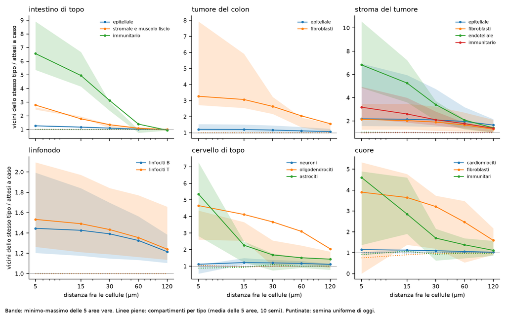

Raggruppamento dei tipi per distanza: tessuti veri (bande fra ROI) contro compartimenti (linee piene) e semina uniforme (puntinate).

Cosa guardare: con la semina uniforme tutte le curve stanno a 1; con i compartimenti la maggior parte entra nelle bande, con eccezioni a grande distanza (immunitarie dell’intestino) e nel cervello.

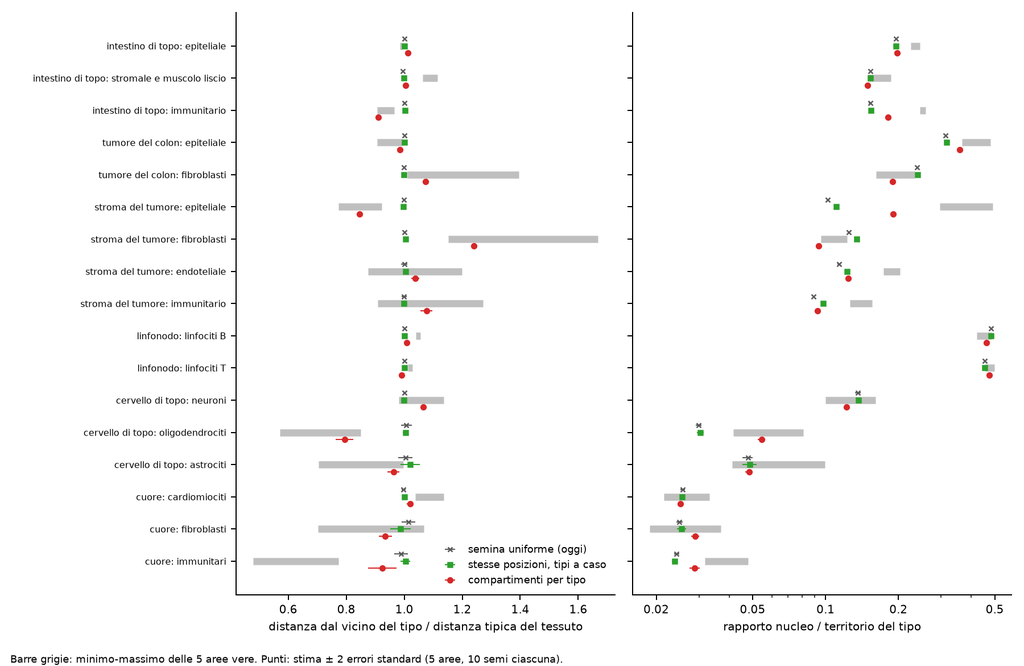

Misure per tipo: distanza relativa dal vicino e rapporto nucleo/territorio, intervallo fra ROI veri contro tre bracci.

Cosa guardare: i punti rossi (compartimenti) si spostano verso le barre grigie dove i tipi hanno densità diverse (stroma, tumore, cervello); i quadrati verdi (stesse posizioni, tipi a caso) restano sulle croci della semina di oggi.

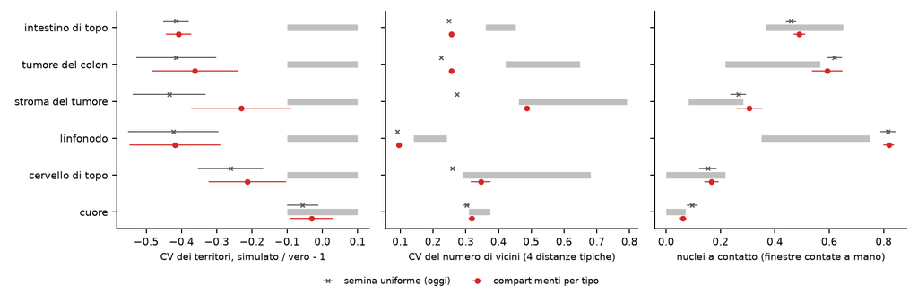

Misure di tessuto: variabilità dei territori, numero di vicini, contatti.

Cosa guardare: la variabilità dei territori resta lontana dalla banda in quattro tessuti; i contatti del linfonodo non cambiano.

# Controprova

CP-1 (stesse posizioni, tipi a caso): conferme spaziali 23 contro 52 del vincente; raggruppamento 4 contro 24 del braccio con le stesse posizioni (C-b). Dettagli nella sezione seguente.

# Dopo il risultato: scelte, deviazioni, post hoc e revisione avversariale

Sezione aggiunta dopo i verdetti. Non cambia previsioni, intervalli o regole. I numeri si rileggono da `results/S1.5c/S1.5c_verdicts.csv`, `S1.5c_rules.csv`, `S1.5c_cp1.csv`, `S1.5c_desc.csv`, `S1.5c_posthoc_terr.csv` e dai file citati riga per riga. Banco generato al commit `be0b9a3` (1 800 unità, 3 worker, 248.7 min); analisi al commit `0aaffb1`.

## Cancelli

| id | esito | dove |
| --- | --- | --- |
| G-1 | PASS: `test_S1.5c.R` 22/22 al primo giro ufficiale, 28/28 dopo i test aggiunti con la revisione; `test_S1.5b.R` 22/22; `test_S1.5.R` 81/83 (falliscono solo E10 ed E10b, come chiuso con DEC-011); `test… | `S1.5c_G1_test.log` |
| G-2 | PASS: 8/8 mutanti pre-registrati rilevati; dopo la revisione 12/12 (M9-M12 sono quattro mutanti del revisore del codice che al primo giro non erano rilevati; M12 è rilevato solo perché i test si ferma… | `S1.5c_G2_mutants.log` |
| G-3 | PASS: 1 800/1 800 unità senza ERROR in C2, C3, C5, C9; 0 cellule non piazzate; braccio di riferimento uguale alle unità ricentrate di S1.5b 300/300 (md5); 6/6 rerun identici, anche con il codice corre… | `S1.5c_G3_check.csv`, `S1.5c_G3_check_after_review.csv`, `S1.5c_md5_before.csv`, `S1.5c_md5_after.csv` |
| G-4 | **FALLITO come scritto, parte a: 75/79 bin entro 0.10** (parte b: 150/150 unità con i parametri della propria piega). I quattro bin fuori: immunitarie dell’intestino a 40-80 µm (0.120), fibroblasti de… | `S1.5c_G4_calcheck.csv`, `S1.5c_G4_mc.csv` |
| G-5 | PASS: ricalcolo indipendente identico in 768/768 verdetti, 3/3 regole, 78/78 celle della controprova, 34 008 metriche per unità, 1 440 contatti per finestra, 660 valori reali, 8 700 righe delle tabell… | revisione avversariale, sotto |

## Regole delle tre scelte

1. **Distanza minima: vince quella per nucleo**, 12 conferme contro 10 fra contatti e distanza relativa dal vicino (`S1.5c_rules.csv`). Nel cuore le due distanze danno simulazioni identiche in 43 unità su 50 (nuclei di taglia simile, distanza minima piccola rispetto alla spaziatura).
2. **Modello di taglia: vince quello del gruppo**, 14 tipi confermati contro 13 del ricentrato (aree dei tessuti 6 contro 6).
3. **Predefinito: la semina a compartimenti NON diventa il predefinito.** Conferme spaziali 52 contro 19 della semina uniforme (su 92), ma conferme delle taglie 20 contro 21. La differenza è un solo verdetto: le cellule quasi senza citoplasma del tumore del colon, 0.0343 ± 0.0006 contro al più 0.0287 (semina uniforme 0.0223, confermata). Fragilità segnalata dal revisore: il conteggio della semina uniforme contiene un verdetto a 0.15 errori standard dal confine (area del nucleo dei fibroblasti dello stroma, 35.56 ± 0.27 contro al più 35.85); con l’esito opposto la regola avrebbe dato «adottata». La regola si applica com’era scritta: la semina a compartimenti resta un’opzione (`spatial = "compartments"`), il predefinito resta la semina uniforme di S1.5b. Decisione tecnica registrata in Semina a compartimenti per tipo: distanza per nucleo, modello di taglia del gruppo, opzione e non predefinito (DEC-020).

## Verdetti (braccio vincente: compartimenti, distanza per nucleo, modello del gruppo)

| previsione | vincente | semina uniforme | nota |
| --- | --- | --- | --- |
| P-1 contatti | confermata in intestino e cervello; indeterminata in tumore del colon (0.593 ± 0.056 contro ≤ 0.567), stroma e cuore; **smentita nel linfonodo** (0.819 contro ≤ 0.75) | 2 confermate, 3 smentite | atteso: indeterminata in tumore e linfonodo. Il linfonodo non cambia: l’eccesso di contatti lì non viene dai tipi |
| P-2 CV dei territori | **smentita in 4 tessuti** (intestino -0.41, tumore del colon -0.36, linfonodo -0.42, cervello -0.21), indeterminata nello stroma (-0.23 ± 0.14), confermata nel cuore | 0 confermate | atteso: confermata in tumore e stroma. Smentita: scarto rilevante, spiegato da PH-1 |
| P-3 rapporto nucleo/territorio del tessuto | confermata 5/6; smentita nell’intestino (0.185 contro ≥ 0.2165) | 3/6 | tornano tumore del colon (0.318) e stroma (0.128) |
| P-4 rapporto nucleo/territorio per tipo | 8/17 confermate | 6/17 | atteso almeno 10: smentita come conteggio; spiegata con P-2 (territori grandi mancanti) |
| P-5 distanza relativa dal vicino per tipo | 10/17 confermate | 4/17 | atteso almeno 9: confermata. Fuori: epitelio, stromale e immunitarie (indeterminata) dell’intestino, linfociti B e T (intervalli stretti, dichiarato), cardiomiociti e immunitarie del cuore |
| P-6 raggruppamento dei tipi (10-20 e 40-80 µm) | 23/34 confermate | 4/34 | confermata nella maggior parte dei tipi |
| P-7 CV del numero di vicini | confermata in stroma, cervello, cuore; smentita in intestino, tumore del colon, linfonodo | 0/6 | come P-2 |
| P-8a area del nucleo del tessuto | 6/6 | 6/6 |  |
| P-8b area del nucleo per tipo | 14/17 | 14/17 | cambiano: epitelio del tumore torna dentro (33.7), fibroblasti dello stroma escono (37.3 contro ≤ 35.85), neuroni escono (97.0 contro ≥ 97.9); astrociti fuori come prima |
| P-8c cellule quasi senza citoplasma, tumore del colon | **smentita**: 0.0343 contro ≤ 0.0287 | confermata 0.0223 | atteso: confermata o indeterminata. Spiegata sotto (D-7) |
| P-9 forma dei territori | 6/6 | 6/6 | il cuore resta isotropo come i territori dei nuclei veri |
| P-10 troncamento | 6/6 | 6/6 |  |

## Controprova

**CP-1 superata.** Il braccio con le stesse posizioni e i tipi mescolati a caso conferma 23 previsioni spaziali contro 52 del vincente. Per tipo: raggruppamento 4 contro 23, distanza relativa dal vicino 4 contro 10, rapporto nucleo/territorio 6 contro 8. Il confronto appaiato giusto (revisione RC-11) è con il braccio che ha esattamente le stesse posizioni (distanza del tessuto, ricentrato): 4 contro 24, 4 contro 9, 6 contro 7; variabilità dei territori e numero di vicini sono identici per costruzione (1 e 3 conferme in entrambi). Le misure per tipo dicono quindi qualcosa sui tipi; quelle che non dipendono dal tipo non migliorano più di quanto migliorino le posizioni.

## Scelte, deviazioni e correzioni dichiarate (dopo il banco)

- **D-5, analisi con pandas 3** (`tools/S1.5c_analysis.py`). Con pandas 3 `astype(str)` lascia i valori mancanti come tali e `groupby` scarta le chiavi mancanti: al primo giro P-5 e P-7 risultavano «non valutabili» in tutti i bracci (nessuna unità). Corretto prima dei verdetti finali (`fillna("")`), con due controlli che fermano l’analisi se manca una metrica. La prima lettura della regola 1 (fatta con P-5 vuota) è superata; i verdetti riportati sono quelli corretti, ricalcolati in modo identico dal revisore.
- **D-6, G-4 fallito come scritto: errore di pre-registrazione della tolleranza.** La tolleranza di 0.10 sul logaritmo supponeva un errore Monte Carlo sotto 0.03; non è vero per i campi con lunghezza di correlazione grande. Due cause, la seconda trovata dalla revisione (RC-05): le curve di Python sono medie di sole 3 repliche, e nella calibrazione le 5 ROI ricevono la stessa realizzazione del campo (seme indipendente dalla ROI, coordinate locali da 0 a 1 000 µm), quindi le 3 repliche sono 3 realizzazioni e non 15. Controprova (`tools/S1.5c_g4_mc.py`, 5 lotti di 10 repliche): fra R a 10 repliche e Python a 50 repliche (5 lotti di 10) lo scarto massimo nei 79 bin controllati (almeno 200 coppie reali dello stesso tipo) è 0.072 sul logaritmo (0.29 nei bin con poche coppie, esclusi dal cancello), e nei 4 bin falliti lo scarto standardizzato è fra -0.2 e 1.0. Il revisore, con una sua implementazione e 240 repliche, trova nessuno scarto standardizzato sopra 3 sui 79 bin e si aspetta per solo rumore in media 7.3 bin oltre 0.10 (ne osserviamo 4). Conseguenza: le due implementazioni sono equivalenti; le curve di calibrazione salvate sono stime rumorose (fino a 0.18 in logaritmo sopra l’attesa del modello) e la scelta dei parametri ne risente (BL-159). Deciso da Luca il 2026-10-23: Il controllo della calibrazione rifatta nel pacchetto, fallito in S1.5c, è un errore della tolleranza pre-registrata, non una differenza fra le due implementazioni (DEC-021).
- **D-7, cellule quasi senza citoplasma nel tumore del colon.** Con i compartimenti l’epitelio riceve territori più piccoli: il rapporto nucleo/territorio dell’epitelio sale da 0.314 a 0.359 (reale 0.367-0.480, ancora sotto), ma la coda sopra 0.95 sale al 3.4 % contro al più il 2.9 % reale. A mediana ancora bassa, la coda è troppo pesante: la dispersione del modello di taglia dell’epitelio (0.50 sul logaritmo) è stata stimata con territori che non dipendevano dal tipo. È il difetto di coda già visto con un tipo solo (DEC-005), riaperto in forma nuova: BL-158.
- **D-8, quote più vincolanti del dichiarato** (revisione RC-01). Nella nota D-1 le proposte rifiutate per quota erano l’1.7 % (tumore del colon, quadrato sintetico). Nei layer del banco (seme 1, 150 unità a compartimenti): mediana 6.6 %, media 8.8 %, massimo 33.6 % (linfonodo p1), con valori alti dove il campo ha lunghezza di correlazione grande rispetto al ROI (linfociti B 512 µm). Le quote impediscono che la composizione di un ROI si allontani da quella del preset, cosa che nei ROI veri succede. In un esperimento del revisore su quadrati sintetici l’effetto su distanza dal vicino e raggruppamento non è rilevabile (provvisorio): BL-160.
- **D-9, test rafforzati dopo la revisione** (RC-02, RC-03, RC-04, RC-09): T6 dopo D-1 verifica la contabilità delle quote, non la composizione estratta da p(x); aggiunti T17 e T17b (tipi estratti da p(x) prima di quote e distanza minima, su una regione a L), T18 (distanza minima fra regioni diverse), T19 (etichette cieche per regione), T20 (distanza per nucleo associata al tipo per nome), T21 (regione troppo sottile per la griglia: ora un punto interno invece di un errore). Il codice aggiunge solo contatori e il ripiego di T21: le 6 unità rigenerate sono identiche al banco (G-3).
- **D-10, rilievi minori dichiarati**: la composizione del cervello usata nella calibrazione (nuclei con tipo di R6: neuroni 0.652) non è quella del preset (corretta per i nuclei persi: 0.700) (RC-06); il bersaglio della calibrazione (tutti i nuclei con tipo come focali, frazione del tessuto) e la metrica di P-6 (celle interne come focali, frazione del ROI) non sono la stessa quantità (RC-07); il caso di una distanza di esattamente 160 µm finiva nel bin sbagliato o dava errore (RC-08: corretto; 0 coppie reali a quella distanza, nessun numero cambia); lambda_max è un’euristica con un limite esatto disponibile (RC-10, nessun superamento in 1 500 unità: BL-161); la regola di inclusione dei ROI per tipo differisce fra P-5/P-6 (almeno 20 celle interne) e P-4/P-8b (tutte) (RC-14, ereditata da S1.5b); solo ℓ e s sono lascia-fuori, composizione, densità del tipo puro e modello di taglia vengono da tutte le ROI come in S1.5b (RC-15); D-2 diceva «senza distorsione» per lo stimatore di T9, ma la selezione delle zone pure lo distorce verso il basso (RC-13).

## Analisi post hoc (dopo i verdetti)

- **PH-1, da dove viene la variabilità dei territori che manca** (`tools/S1.5c_posthoc.py`, `S1.5c_posthoc_terr.csv`). Celle interne, media delle 5 ROI. Nei tessuti veri il 5.2 % dei territori dell’intestino supera 3 volte la mediana (tumore del colon 5.1 %, stroma 9.2 %, cervello 3.1 %), contro lo 0.4-0.7 % del simulato vincente (stroma 4.1 %); nell’intestino, nel tumore del colon e nello stroma il 99° percentile vale 4.8-6.6 volte la mediana nel vero e 2.7-4.0 nel simulato. Togliendo i territori sopra 3 volte la mediana, il CV vero scende da 0.80 a 0.54 nell’intestino (simulato 0.469 → 0.455) e da 0.78 a 0.55 nel tumore del colon (simulato 0.48 → 0.45). La parte che manca è quindi soprattutto la coda dei territori molto grandi: cellule al bordo di spazi vuoti dentro il tessuto (lumi delle ghiandole e delle cripte, spazi fra le strutture), che la figura 4 mostra nell’intestino e nel tumore del colon e che la semina, uniforme o a compartimenti, riempie di cellule (BL-157). Nel linfonodo la coda è piccola anche nel vero (0.5 %): lì manca la variabilità del corpo della distribuzione (q90 1.53 contro 1.32).
- **Descrittive**: tempo mediano per unità con i compartimenti da 1.1 a 4.3 volte quello della semina uniforme (intestino 37.9 contro 29.0 s, stroma 12.9 contro 3.0 s); D-desc-1 (cuore senza i territori con frammenti ricevuti): -0.043 ± 0.059, a cavallo del limite -0.10: il cuore resta fragile come in S1.5; distanza dal vicino divisa per la somma dei raggi (D-desc-3): la frazione sotto 1 cambia poco (tumore del colon 0.557 → 0.592, reale 0.508).

## Revisione avversariale

Due revisori indipendenti, in sola lettura sul repo e con codice proprio (`/mnt/micron/geo_spatialtrans/S1.5c/review_recalc`, `review_code`; risposte strutturate in `results/S1.5c/S1.5c_review.json`).

- **Ricalcolo** (G-5): nessuna discrepanza (numeri sopra). Limiti dichiarati: i contatti sono ricalcolati dal raster dell’autore, non rasterizzando di nuovo i nuclei; l’indicatore di cella interna è ricalcolato solo nelle 12 unità rigenerate; la convenzione del sottocampione di 1 500 focali è stata copiata per confrontare a 1e-9 (con tutti i focali cambiano 78 valori del raggruppamento, nessun verdetto riportato come cambiato). Due osservazioni portate nel riassunto: la fragilità della regola 3 e le curve di calibrazione rumorose.
- **Codice**: nessun errore che cambi numeri o verdetti. 15 rilievi (RC-01…RC-15), tutti trattati sopra (D-8, D-9, D-10, D-6, CP-1). Mutanti del revisore: 12/16 rilevati al primo giro; i 4 non rilevati (etichette cieche su tutto il tessuto, aree nucleari in ordine inverso, griglia sul riquadro, distanza minima solo dentro la regione) sono ora rilevati (G-2, M9-M12). Verificato dal revisore sui dati del banco: parametri lascia-fuori del ROI simulato, semi, regola della cella interna uguale nel vero e nel simulato, stessa funzione delle metriche, a_t convergenti (residuo < 1e-12), nessun superamento di lambda_max, distanza minima rispettata anche fra tipi e regioni.

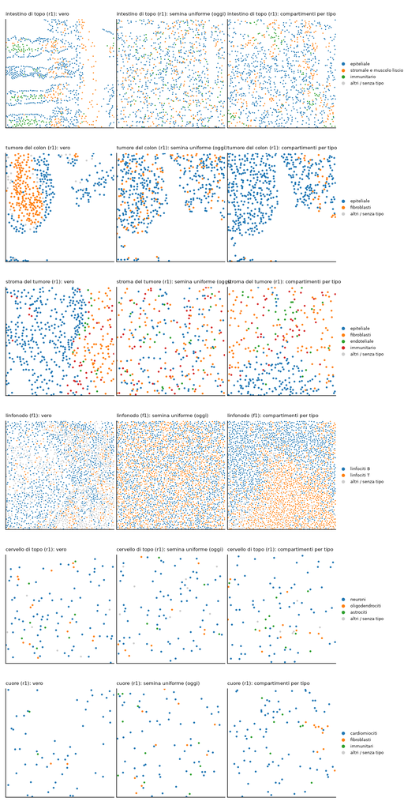

Un riquadro di 300 µm per tessuto: nuclei veri con il tipo, semina di oggi, compartimenti per tipo (seme 1).

Cosa guardare: nei tessuti veri intestino e tumore del colon hanno spazi vuoti (lumi) dentro il tessuto, che la semina riempie; i compartimenti danno zone per tipo ma rotonde, non le bande delle cripte.

# Cosa è girato

- Banco: 1 800 unità (30 ROI × 10 semi × 6 bracci), seme = 20261021 + 1000 · i + s come S1.5 e S1.5b, generato al commit `be0b9a3` su lesexp-server con 3 worker a un thread in 248.7 minuti (con MMM in corsa).
- Calibrazione dei compartimenti al commit `1142efa` (prima della pre-registrazione), 6 tessuti in parallelo.
- md5 degli 88 file letti: identici prima e dopo.

Tempo mediano di place_cells() per unità (s)

| archetype | est.U | est.C-a | est.C-b | est.N-a | est.N-b | est.G |
| --- | --- | --- | --- | --- | --- | --- |
| A1 | 29.0 | 37.7 | 37.7 | 37.9 | 37.5 | 37.7 |
| A2 | 16.8 | 18.2 | 18.4 | 18.4 | 18.1 | 18.5 |
| A3 | 3.0 | 13.1 | 12.9 | 12.9 | 13.0 | 13.1 |
| A4 | 27.3 | 31.7 | 31.7 | 31.8 | 31.4 | 31.6 |
| A5 | 15.9 | 23.4 | 23.4 | 23.3 | 23.3 | 23.4 |
| A6 | 7.3 | 11.4 | 11.5 | 11.5 | 11.5 | 11.4 |

# Appendice

## Pre-registrazione (testo del file dello step)

Commit dei cancelli e delle previsioni: `1142efa`. Ok di Luca sulle previsioni, sugli intervalli e sulle tre regole: 2026-10-23, in chat, alla domanda «Approvi le previsioni con i loro intervalli e le tre regole (distanza minima, modello di taglia, cambio del predefinito) come scritte sopra e nel file dello step?»: «Approvo così». Commit: vedi `git log` (messaggio «S1.5c: ok di Luca sulle previsioni»).

## Cosa si implementa (scritto prima del codice)

**Semina a compartimenti** in `R/04b2_seed_centroids.R`: nuovo argomento `spatial = c("uniform", "compartments")` (predefinito `"uniform"`: comportamento di S1.5b invariato, bit per bit) e, per `"compartments"`, una tabella `compartments` (`cell_type`, `ell_um`, `s`), `min_dist_mode = c("tissue", "nucleus")`, `labels = c("field", "blind")`. Per ogni regione:

1. Per ogni tipo con s > 0, un campo gaussiano latente Z_t(x) a media 0 e varianza 1, covarianza exp(-r² / (2 ℓ_t²)), costruito con 256 caratteristiche di Fourier casuali (Z = √(2/256) Σ cos(ω_k · x + b_k), ω_k ~ N(0, I/ℓ_t²), b_k ~ U(0, 2π)), coordinate assolute in µm. Tipi con s = 0 (i tipi minori, sotto il 5 % del tessuto): nessun campo.
2. Probabilità locali dei tipi (per numero di cellule): p_t(x) = softmax_t(log f_t + a_t + s_t Z_t(x)), f_t = composizione del preset.
3. Densità locale: λ(x) = c / Σ_t p_t(x) / ρ_t, con ρ_t = densità del tipo puro già nel catalogo di S1.5b (B-186…B-208: la densità a cui il territorio mediano è quello reale del tipo). Dove le cellule sono di un tipo solo la densità è quella del tipo; nelle miscele è la media armonica, come oggi per la regione.
4. a_t e c si fissano su una griglia di punti della regione (passo min(ℓ_min/2, √(area/4000))) in modo che le frazioni attese per numero, pesate con λ, siano f_t e che ∫λ = densità manuale × area: il numero di cellule della regione resta quello di oggi (stesso arrotondamento stocastico).
5. Proposte uniformi nella regione, accettate con probabilità λ(x)/λ_max (diradamento); al punto accettato si estrae il tipo da p(x); poi il controllo della distanza minima (RSA) con la distanza della coppia (d_i + d_j)/2. Un solo processo per regione, tipi mescolati: nessun ordine di semina per tipo (BL-055). Nessuna quota per tipo: la composizione realizzata varia attorno a f_t (il controllo C4 può dare WARN).
6. `min_dist_mode = "tissue"`: d_t = d* del tessuto per ogni tipo (DEC-009). `"nucleus"`: d_t = κ · 2 √(a_t / π), con a_t = area nucleare mediana reale del tipo (`S1.5b_type_calibration.csv`) e κ tale che Σ f_t d_t = d*: la media resta d*, i tipi con nuclei grandi si distanziano di più.
7. `labels = "blind"` (solo per la controprova): stesse posizioni del modo `"field"` con lo stesso seme, etichette permutate a caso dentro la regione.

`place_cells()` e `tissue_preset_spec()`: argomento `spatial` passato alla semina; la tabella `compartments` del preset viene dalla calibrazione su tutte le ROI (righe nuove di BIO_REFERENCES da B-209); `override_compartments` per passarne un’altra.

**Calibrazione** (`tools/S1.5c_calibration.py`, già eseguita, risultati committati con questo file)[^calib]. Bersaglio: il rapporto di connessione dei tipi principali, R_t(b) = P(vicino di tipo t | cellula di tipo t, distanza in b) / f_t, nei bin 0-10, 10-20, 20-40, 40-80, 80-160 µm, sui nuclei veri con un tipo. Le etichette simulate si estraggono **sulle posizioni dei nuclei veri** (approssimazione dichiarata: la calibrazione non contiene l’accoppiamento fra tipo e densità del punto 3). Griglia ℓ ∈ {8, 16, 32, 64, 128, 256, 512} µm, s ∈ {0, 0.5, …, 4, 5, 6}, discesa per coordinate (2 giri), 3 repliche dei campi. Pieghe: lascia-fuori-un-ROI (i parametri del ROI k si stimano sugli altri 4) e tutte le 5 ROI (il preset). La perdita scende da 34 a 108 volte rispetto a s = 0, secondo il tessuto. Limiti visti nella calibrazione, dichiarati ora: diversi parametri stanno al bordo della griglia (s = 6; ℓ = 8 o 512 µm), i parametri cambiano fra pieghe (per esempio cervello: neuroni ℓ = 64 µm senza la ROI r1, che contiene sostanza bianca, 128-512 con), e il campo non può produrre la repulsione fra neuroni entro 10 µm (reale 0.85, adattato 1.28).

**Banco** `tools/S1.5c_bench.R`: come S1.5b (30 ROI × 10 semi, maschera di tessuto valido di R2 a un solo cluster, seme = 20261021 + 1000 · i + s, stessi argomenti), con i parametri della piega lascia-fuori del ROI simulato; uscite in `/mnt/micron/geo_spatialtrans/S1.5c/`, un file per unità, rilanciabile, worker dal file `WORKERS` (al più 3 finché gira MMM, poi fino a 20). Contatti con l’operatore di S1.4d e S1.5 (nuclei rasterizzati sulla griglia nativa, finestre di R2c, media a peso uguale delle 4 finestre per seme). Sei bracci, 1 800 unità:

| braccio | semina | distanza minima | modello di taglia | ruolo |
| --- | --- | --- | --- | --- |
| U | uniforme, cieca al tipo (S1.5b) | tessuto | ricentrato | riferimento (= S1.5b) |
| C-a | compartimenti | tessuto | del gruppo | candidato |
| C-b | compartimenti | tessuto | ricentrato | candidato |
| N-a | compartimenti | per nucleo | del gruppo | candidato |
| N-b | compartimenti | per nucleo | ricentrato | candidato |
| G | compartimenti, etichette cieche | tessuto | ricentrato | controprova CP-1 |

Il braccio ricentrato di S1.5b correggeva il fatto che il territorio non dipendeva dal tipo (DEC-019); con territori per tipo la correzione può diventare doppia, per questo i due modelli di taglia si rimettono a confronto. In G il territorio non dipende dal tipo, quindi si usa il ricentrato.

**Metriche** (`tools/S1.5c_metrics.py`, stesse funzioni per reale e simulato; cella interna con la regola di R3, invariata): - `nn_rel_t`: mediana della distanza dal vicino più vicino (di qualsiasi tipo) delle celle interne del tipo t divisa per la stessa mediana su tutte le celle interne. Adimensionale: non dipende dalla differenza fra la densità dei nuclei segmentati (reale) e quella manuale (simulato). - `markconn_t(b)`: rapporto di connessione dei tipi come nella calibrazione, focali = celle interne del tipo (al più 1 500, seme fisso). - `cv_local4`: CV del numero di vicini entro 4 volte la distanza mediana dal vicino più vicino (raggio relativo, stesso numero atteso di vicini nel reale e nel simulato). - le altre come in S1.5 e S1.5b (contatti, CV dei territori appaiato per ROI, rapporto nucleo/territorio, aree nucleari, troncamento, eccentricità).

## Note di sviluppo (scritte prima della corsa ufficiale dei cancelli e del banco; non cambiano previsioni né intervalli)

Esposizioni in sviluppo: solo tessuti sintetici (quadrati pieni di 120-1 500 µm a 1 µm/px) e i nuclei veri per la calibrazione e per gli intervalli reali (già committati). Nessuna simulazione sulle 30 ROI prima del banco: una prova sul ROI r1 del tumore del colon è stata lanciata e annullata prima di leggerne l’uscita, e sostituita da un quadrato sintetico.

- **D-1, quote per tipo (deviazione dalla definizione pre-registrata).** Il punto 5 diceva «nessuna quota per tipo». Il primo giro dei test ha fatto fallire T6 (composizione media su 200 semi): epitelio del tumore del colon 0.7647 contro 0.7764, 6 errori Monte Carlo sotto. Causa: la distanza minima rifiuta più spesso le proposte dove la densità è alta, quindi i tipi densi restano sotto la loro quota attesa. Correzione: ogni regione ha le quote per tipo ripartite dal piano, come in S1.5b; il tipo si estrae sempre da p(x) e la proposta il cui tipo ha esaurito la quota è rifiutata (non si forza un tipo in un posto dove p(x) non lo mette). Dopo la correzione T6 passa (0.7766 contro 0.7764). Test aggiunto T6b: le proposte rifiutate per quota sono in media l’1.7 % (soglia 5 %); senza gli spostamenti a_t (mutante M3) il 47 %. Con le quote la descrittiva D-desc-2 (composizione realizzata) diventa esatta per costruzione.
- **D-2, stimatore della densità in T9.** La prima versione usava la mediana di (k - 1) / (π r_k²) con k = 10: la mediana sottostima la densità di un processo di Poisson di circa il 7 % (1/G con G ~ Gamma(10)), quindi il test confrontava una quantità distorta con la soglia del 10 %. Ora la densità è il numero medio di vicini entro 40 µm diviso per l’area del cerchio (stimatore senza distorsione), sui centri le cui vicine entro 40 µm sono tutte dello stesso tipo e lontani dal bordo. Esito: 3 721 e 998 per mm² contro 4 000 e 1 000 (soglia e definizione del test invariate).
- **D-3, area nucleare mediana per tipo** per la distanza per nucleo: calcolata da `tools/S1.5c_type_nuc_area.py` (tutti i nuclei con un tipo, etichette R6 PH-1, come la regola dei gruppi di S1.5b), `S1.5c_type_nuc_area.csv`; righe B-209…B-231 di BIO_REFERENCES con ℓ, s e a_t.
- **D-4, mutanti come copie del codice.** I mutanti di G-2 sono applicati da `run_S1.5c.sh` a una copia di `R/04b*.R` e di `tools/S1.5c_bench_lib.R` in una cartella temporanea, senza interruttori nel codice di produzione (rilievo di BL-155). M2 è realizzato come «λ_max = media invece del massimo» (la densità relativa non è più normalizzata al suo massimo).

## Scelte decise dai dati (regole scritte prima del banco)

1. **Distanza minima (tessuto o per nucleo).** Sui bracci con il modello di taglia del gruppo (C-a contro N-a): vince quello con più conferme fra P-1 (6 tessuti) e P-5 (17 tipi); a parità, la distanza del tessuto, perché non aggiunge ipotesi (DEC-009).
2. **Modello di taglia** sulla distanza vincente: la regola di S1.5b (più tipi confermati in P-8b; a parità più tessuti confermati in P-8a; a parità ancora, il modello del gruppo).
3. **Predefinito dei preset.** La semina a compartimenti del braccio vincente diventa il predefinito di `tissue_preset_spec()` e `place_cells()` se, rispetto a U, conferma più previsioni nell’insieme spaziale (P-1…P-7) **e** almeno altrettante nell’insieme delle taglie (P-8). Altrimenti resta un’opzione e il predefinito resta la semina uniforme; il motivo diventa un dubbio dello step.

Le previsioni si giudicano sul braccio vincente; gli altri si riportano accanto.

## Cancelli (al massimo 5)

| id | controllo | tolleranza | comando |
| --- | --- | --- | --- |
| G-1 | **batteria di test** `R/testing/test_S1.5c.R`: campo (media 0, varianza 1, correlazione a distanza ℓ uguale a e^(-1/2) entro l’errore Monte Carlo su 200 campi); frazioni attese pesate con λ = f_t (1e-… | tutte PASS salvo i due FAIL noti | `bash R/testing/run_S1.5c.sh test` |
| G-2 | **mutanti**: M1 campo ignorato (s = 0); M2 λ non normalizzata; M3 a_t non risolti; M4 distanza della coppia = massimo invece della media; M5 frequenze del campo con scala ℓ invece di 1/ℓ; M6 ρ_t ignor… | 8/8 rilevati | `bash R/testing/run_S1.5c.sh mutants` |
| G-3 | **invarianti, riproducibilità, compatibilità** sulle 1 800 unità: C2, C3, C5, C9 senza ERROR; 0 cellule non piazzate; braccio U uguale alle unità ricentrate di S1.5b (md5, 300/300); rerun di 6 unità i… | 0 ERROR, 0 non piazzate, 300/300, 6/6, md5 invariati | `Rscript --vanilla tools/S1.5c_bench.R check` |
| G-4 | **calibrazione ricalcolata in R**: le etichette del pacchetto (stesse formule, generatore di R) sulle posizioni dei nuclei veri con i parametri di tutte le ROI riproducono le curve di `S1.5c_compartme… |  | Δ log R |
| G-5 | **ricalcolo indipendente** della revisione avversariale: due revisori ricalcolano P-1…P-10, CP-1 e le tre regole dal codice e dai dati | identico o ≤ 1e-9 | revisione |

## Previsioni

Unità indipendente: **ROI** (5 per tessuto; valore del ROI = media dei 10 semi; stima = media dei 5 ROI ± 2 errori standard, errore standard = deviazione standard fra ROI / √5), appaiato al reale dello stesso ROI dove la previsione lo dice; **seme** per P-1 (finestre fisse), come S1.5. Nessun bootstrap. Intervalli «fra ROI reali» = [minimo, massimo] dei 5 ROI reali (3 nel cervello per astrociti e oligodendrociti: solo 3 ROI hanno almeno 20 celle interne del tipo), calcolati prima di ogni simulazione[^realrefs]. Gli attesi sono stime a mano, per il braccio C-a.

| id | quantità | tessuto | atteso (braccio C-a) | intervallo di rilevanza | fonte | 2 errori standard tipici |
| --- | --- | --- | --- | --- | --- | --- |
| P-1 | frazione di nuclei a contatto, finestre di R2c a peso uguale | intestino / tumore del colon / stroma / linfonodo / cervello / cuore | verso i valori con i centri veri (0.50, 0.50, 0.18, 0.74, 0.07, 0.05, S1.5 PH-1): confermata in intestino, stroma, cervello, cuore; **indeterminata** in tumore del colon e linfonodo (direzione non not… | 0.366-0.650 / 0.217-0.567 / 0.083-0.283 / 0.350-0.750 / 0.000-0.217 / 0.000-0.070 | B-127…B-132 (manuale, due stadi), P-5 di S1.5 | ≈ 0.03 |
| P-2 | CV dell’area dei territori, simulato / reale - 1, appaiato per ROI | 6 tessuti | sale da -0.26…-0.43 (U) verso 0: confermata in tumore del colon e stroma (densità dei tipi fino a 3 volte diverse); indeterminata in intestino e cervello; **smentita** nel linfonodo (linfociti B e T a… | -0.10…+0.10 | soglia di S1.3 (B-2), approvata da Luca il 2026-10-08; P-6 di S1.5 | 0.04-0.13 |
| P-3 | rapporto mediano nucleo/territorio del tessuto, celle interne | 6 tessuti | confermata in tumore del colon, stroma, linfonodo, cervello, cuore; intestino indeterminata | 0.2165-0.2309 / 0.3094-0.4334 / 0.1166-0.3371 / 0.4491-0.5013 / 0.0821-0.1108 / 0.0235-0.0366 | P-2 di S1.5 | < 0.005 |
| P-4 | rapporto mediano nucleo/territorio per tipo, celle interne, tipi principali | 17 tipi | confermata in almeno 10 tipi su 17 (U: 6) | fra ROI reali per tipo | P-7 di S1.5b (`S1.5b_real_refs_roi_type.csv`) | < 0.005 |
| P-5 | distanza relativa dal vicino per tipo (`nn_rel_t`) | 17 tipi | U ≈ 1 per ogni tipo, confermata solo dove l’intervallo contiene 1; C-a: confermata in almeno 9 tipi su 17 (per esempio immunitarie del cuore ≈ 0.75 contro 0.48-0.77, fibroblasti dello stroma ≈ 1.2 con… | fra ROI reali per tipo | `S1.5c_real_intervals.csv` | ≈ 0.01-0.03 |
| P-6 | rapporto di connessione dei tipi a 10-20 µm e a 40-80 µm | 17 tipi × 2 distanze | U = 1, confermata solo dove l’intervallo contiene 1; C-a: confermata nella maggior parte dei tipi a 10-20 µm; a 40-80 µm indeterminata dove i parametri cambiano fra pieghe (cervello, linfonodo); neuro… | fra ROI reali | `S1.5c_real_intervals.csv` | 0.05-0.3 |
| P-7 | CV del numero di vicini entro 4 distanze mediane dal vicino (`cv_local4`), celle interne | 6 tessuti | sale verso il reale; confermata in tumore del colon e stroma; **smentita** nel linfonodo (come P-2); indeterminata negli altri | 0.360-0.452 / 0.421-0.648 / 0.461-0.791 / 0.141-0.241 / 0.291-0.682 / 0.309-0.375 | fra ROI reali (`S1.5c_real_intervals.csv`) | ≈ 0.02 |
| P-8a | area mediana del nucleo, celle interne (regressione) | 6 tessuti | confermata 6/6 | intervalli di P-1 di S1.5b | P-1 di S1.5b | come S1.5b |
| P-8b | area mediana del nucleo per tipo (regressione) | 17 tipi | almeno 14 confermati, come S1.5b (astrociti smentita, attesa) | intervalli di P-2 di S1.5b | P-2 di S1.5b | come S1.5b |
| P-8c | cellule quasi senza citoplasma (nucleo ≥ 0.95 del territorio) | tumore del colon | confermata o indeterminata: territori più piccoli dell’epitelio alzano la coda | 0-0.0287 | P-5 di S1.5b | ≈ 0.002 |
| P-9 | eccentricità mediana del territorio, simulato - reale (regressione) | 6 tessuti | confermata 6/6; nel cuore la forma vera dei cardiomiociti resta fuori dal Voronoi isotropo (controllo negativo previsto; R3 ha mostrato che anche i territori dei nuclei veri sono isotropi, quindi qui … | -0.05…+0.05 | P-7 di S1.5 (soglia di S1.3, B-4) | ≈ 0.01 |
| P-10 | frazione di nuclei troncati dal tetto φ | 6 tessuti | confermata 6/6 | 0-0.05 | criterio di Luca (S1.4), P-6 di S1.5b | ≈ 0.003 |

Cosa direbbe una smentita.

- **P-1 smentita** in tumore del colon o linfonodo: i compartimenti non spiegano l’eccesso di contatti; resterebbe la distanza a corto raggio (distanza minima legata alla taglia, scelta 1) o un difetto del modello del nucleo a contatto.
- **P-2, P-7 smentite** dove i tipi hanno densità diverse (tumore del colon, stroma): la densità che dipende dal tipo non basta, serve un’eterogeneità della densità che non viene dai tipi. Nel linfonodo la smentita è attesa e dice questo stesso.
- **P-4, P-5 smentite** in molti tipi: le zone di un solo tipo sono troppo mescolate per dare al tipo il suo territorio, oppure la densità del tipo puro di S1.5b non è quella giusta.
- **P-6 smentita**: la calibrazione sulle posizioni vere non si trasferisce alla semina (accoppiamento con la densità) o non si trasferisce fra ROI (pieghe).
- **P-8 smentita** dove S1.5b confermava: il modello di taglia per tipo dipendeva dalla semina cieca; si guarda il modello di taglia scelto dalla regola 2.

## Controprova

**CP-1, aggregazione senza tipi (braccio G).** Stesse posizioni e stessa densità locale del braccio a compartimenti, etichette dei tipi permutate a caso. Se il passo funziona perché i tipi stanno nei loro compartimenti, G deve fare peggio del braccio vincente in P-4, P-5 e P-6, mentre P-2 e P-7 (che dipendono solo dalle posizioni) restano uguali. Attesi: P-6 confermata in G solo dove l’intervallo contiene 1; P-4 e P-5 confermate in meno tipi del vincente. Se G facesse altrettanto bene in P-4, P-5 e P-6, le misure per tipo non direbbero nulla sui tipi. La soglia è il risultato del braccio vincente, non un numero fissato prima (lezione di BL-151).

## Descrittive (senza verdetto)

- D-desc-1 (F-1 di S1.5): P-2 nel cuore escludendo i territori che hanno ricevuto frammenti staccati.
- D-desc-2: composizione realizzata per unità contro f_t (WARN di C4), perché la semina a compartimenti non fissa le quote.
- D-desc-3: distanza dal vicino divisa per la somma dei raggi dei due nuclei (quantile 5 % e frazione sotto 1), reale contro bracci.
- D-desc-4: tempo di `place_cells()` per unità contro U.
- D-desc-5: figura con i tipi per un ROI di ogni tessuto, reale, U e vincente, accanto all’H&E.

## Calibrazione dei compartimenti

Parametri su tutte le ROI (preset, B-209…B-231)

| archetype | cell_type | ell_um | s | f_t | loss | loss_null |
| --- | --- | --- | --- | --- | --- | --- |
| A1 | epiteliale | 32 | 5.0 | 0.685 | 162.442 | 8561.700 |
| A1 | stromale e muscolo liscio | 8 | 6.0 | 0.214 | 162.442 | 8561.700 |
| A1 | immunitario | 32 | 4.0 | 0.101 | 162.442 | 8561.700 |
| A2 | epiteliale | 128 | 6.0 | 0.776 | 52.560 | 5691.372 |
| A2 | fibroblasti | 32 | 4.0 | 0.224 | 52.560 | 5691.372 |
| A3 | epiteliale | 128 | 6.0 | 0.407 | 281.566 | 15386.270 |
| A3 | fibroblasti | 512 | 3.0 | 0.325 | 281.566 | 15386.270 |
| A3 | endoteliale | 32 | 3.5 | 0.081 | 281.566 | 15386.270 |
| A3 | immunitario | 16 | 2.5 | 0.186 | 281.566 | 15386.270 |
| A4 | linfociti B | 512 | 4.0 | 0.495 | 10.617 | 1102.585 |
| A4 | linfociti T | 16 | 1.0 | 0.417 | 10.617 | 1102.585 |
| A5 | neuroni | 128 | 6.0 | 0.652 | 216.609 | 7291.512 |
| A5 | oligodendrociti | 512 | 5.0 | 0.198 | 216.609 | 7291.512 |
| A5 | astrociti | 8 | 6.0 | 0.066 | 216.609 | 7291.512 |
| A6 | cardiomiociti | 64 | 3.0 | 0.758 | 92.524 | 3605.617 |
| A6 | fibroblasti | 512 | 2.0 | 0.128 | 92.524 | 3605.617 |
| A6 | immunitari | 8 | 5.0 | 0.115 | 92.524 | 3605.617 |

Intervallo dei parametri fra le 5 pieghe lascia-fuori

| archetype | cell_type | ell_um | s |
| --- | --- | --- | --- |
| A5 | astrociti | 8-8 | 6-6 |
| A6 | cardiomiociti | 32-128 | 2.5-5 |
| A3 | endoteliale | 16-32 | 2-4 |
| A1 | epiteliale | 32-32 | 4-6 |
| A2 | epiteliale | 32-128 | 4-6 |
| A3 | epiteliale | 128-256 | 6-6 |
| A2 | fibroblasti | 32-256 | 3-6 |
| A3 | fibroblasti | 64-128 | 3-5 |
| A6 | fibroblasti | 256-512 | 0.5-2.5 |
| A6 | immunitari | 8-16 | 2-6 |
| A1 | immunitario | 16-32 | 3.5-5 |
| A3 | immunitario | 8-16 | 2-3.5 |
| A4 | linfociti B | 64-512 | 2-4 |
| A4 | linfociti T | 8-256 | 1-1.5 |
| A5 | neuroni | 64-512 | 2.5-6 |
| A5 | oligodendrociti | 16-512 | 2.5-6 |
| A1 | stromale e muscolo liscio | 8-8 | 6-6 |

## Post hoc: coda dei territori

Area del territorio / mediana (celle interne), media dei 5 ROI

| archetype | source | q10 | q90 | q99 | frac_gt3 | cv | cv_trim |
| --- | --- | --- | --- | --- | --- | --- | --- |
| A1 | N-a | 0.520 | 1.768 | 2.654 | 0.004 | 0.469 | 0.455 |
| A2 | N-a | 0.550 | 1.790 | 2.834 | 0.007 | 0.476 | 0.448 |
| A3 | N-a | 0.416 | 2.340 | 3.979 | 0.041 | 0.674 | 0.578 |
| A4 | N-a | 0.765 | 1.319 | 1.641 | 0.000 | 0.214 | 0.214 |
| A5 | N-a | 0.463 | 1.860 | 2.785 | 0.007 | 0.518 | 0.497 |
| A6 | N-a | 0.442 | 1.933 | 2.999 | 0.011 | 0.551 | 0.518 |
| A1 | reale | 0.488 | 2.362 | 4.820 | 0.052 | 0.795 | 0.536 |
| A2 | reale | 0.448 | 2.356 | 5.081 | 0.051 | 0.779 | 0.554 |
| A3 | reale | 0.378 | 2.980 | 6.597 | 0.092 | 0.914 | 0.621 |
| A4 | reale | 0.719 | 1.534 | 2.546 | 0.005 | 0.388 | 0.330 |
| A5 | reale | 0.422 | 2.170 | 3.874 | 0.031 | 0.670 | 0.555 |
| A6 | reale | 0.437 | 1.951 | 3.257 | 0.016 | 0.571 | 0.525 |
| A1 | U | 0.525 | 1.758 | 2.623 | 0.004 | 0.463 | 0.450 |
| A2 | U | 0.553 | 1.712 | 2.512 | 0.002 | 0.436 | 0.428 |
| A3 | U | 0.484 | 1.814 | 2.735 | 0.005 | 0.495 | 0.479 |
| A4 | U | 0.766 | 1.316 | 1.636 | 0.000 | 0.212 | 0.212 |
| A5 | U | 0.510 | 1.811 | 2.690 | 0.005 | 0.488 | 0.468 |
| A6 | U | 0.451 | 1.896 | 2.908 | 0.009 | 0.537 | 0.510 |

## Controllo della calibrazione (G-4) e indagine Monte Carlo

Curve adattate: Python a 3 repliche (calibrazione), Python a 50 repliche (5 lotti), R a 10 repliche (G-4)

| archetype | cell_type | bin | real_pairs | R_real | R_fit_py3 | py10_mean | R_fit_R10 | sd_log_3rep | z_R10_vs_py10 |
| --- | --- | --- | --- | --- | --- | --- | --- | --- | --- |
| A1 | epiteliale | 0-10 | 27815 | 1.270 | 1.269 | 1.269 | 1.274 | 0.003 | 1.747 |
| A1 | epiteliale | 10-20 | 65294 | 1.153 | 1.181 | 1.180 | 1.184 | 0.004 | 1.179 |
| A1 | epiteliale | 20-40 | 200095 | 1.053 | 1.105 | 1.106 | 1.113 | 0.005 | 1.511 |
| A1 | epiteliale | 40-80 | 642773 | 1.029 | 1.023 | 1.025 | 1.033 | 0.003 | 3.035 |
| A1 | epiteliale | 80-160 | 1847765 | 0.991 | 0.997 | 0.998 | 1.002 | 0.002 | 2.208 |
| A1 | stromale e muscolo liscio | 0-10 | 4524 | 2.628 | 2.866 | 2.818 | 2.820 | 0.008 | 0.115 |
| A1 | stromale e muscolo liscio | 10-20 | 10243 | 1.966 | 1.883 | 1.809 | 1.820 | 0.014 | 0.568 |
| A1 | stromale e muscolo liscio | 20-40 | 21998 | 1.304 | 1.405 | 1.367 | 1.381 | 0.030 | 0.418 |
| A1 | stromale e muscolo liscio | 40-80 | 65240 | 1.150 | 1.104 | 1.091 | 1.106 | 0.034 | 0.539 |
| A1 | stromale e muscolo liscio | 80-160 | 187864 | 0.987 | 1.001 | 1.002 | 0.997 | 0.024 | -0.250 |
| A1 | immunitario | 0-10 | 3852 | 6.457 | 5.858 | 6.045 | 6.091 | 0.016 | 0.604 |
| A1 | immunitario | 10-20 | 8530 | 4.947 | 4.635 | 4.662 | 4.653 | 0.019 | -0.128 |
| A1 | immunitario | 20-40 | 14287 | 2.772 | 3.042 | 3.069 | 3.079 | 0.028 | 0.153 |
| A1 | immunitario | 40-80 | 12290 | 0.950 | 1.316 | 1.451 | 1.484 | 0.033 | 0.893 |
| A1 | immunitario | 80-160 | 44983 | 1.043 | 0.925 | 0.997 | 1.008 | 0.032 | 0.436 |
| A2 | epiteliale | 0-10 | 23530 | 1.275 | 1.206 | 1.214 | 1.212 | 0.005 | -0.302 |
| A2 | epiteliale | 10-20 | 71147 | 1.236 | 1.190 | 1.199 | 1.198 | 0.006 | -0.186 |
| A2 | epiteliale | 20-40 | 226808 | 1.171 | 1.149 | 1.165 | 1.162 | 0.009 | -0.362 |
| A2 | epiteliale | 40-80 | 703719 | 1.110 | 1.088 | 1.114 | 1.110 | 0.012 | -0.415 |
| A2 | epiteliale | 80-160 | 2188671 | 1.072 | 1.039 | 1.063 | 1.062 | 0.012 | -0.101 |
| A2 | fibroblasti | 0-10 | 3913 | 4.190 | 3.515 | 3.573 | 3.566 | 0.021 | -0.112 |
| A2 | fibroblasti | 10-20 | 11789 | 3.557 | 3.310 | 3.398 | 3.397 | 0.025 | -0.020 |
| A2 | fibroblasti | 20-40 | 35657 | 2.717 | 2.818 | 2.974 | 2.975 | 0.042 | 0.008 |
| A2 | fibroblasti | 40-80 | 97446 | 2.036 | 2.087 | 2.348 | 2.323 | 0.059 | -0.233 |
| A2 | fibroblasti | 80-160 | 263157 | 1.642 | 1.499 | 1.718 | 1.707 | 0.065 | -0.126 |
| A3 | epiteliale | 0-10 | 11966 | 2.371 | 2.072 | 2.038 | 2.027 | 0.040 | -0.174 |
| A3 | epiteliale | 10-20 | 37363 | 2.311 | 2.036 | 2.007 | 1.999 | 0.036 | -0.132 |
| A3 | epiteliale | 20-40 | 122561 | 2.219 | 1.940 | 1.934 | 1.928 | 0.038 | -0.116 |
| A3 | epiteliale | 40-80 | 376893 | 2.099 | 1.749 | 1.791 | 1.784 | 0.050 | -0.102 |
| A3 | epiteliale | 80-160 | 988247 | 1.908 | 1.385 | 1.491 | 1.474 | 0.074 | -0.200 |

[output cut: 55 more lines]

## Da dove vengono i numeri del riassunto

| frase del riassunto | fonte | valore letto |
| --- | --- | --- |
| 52 misure su 92, contro 19 | S1.5c_cp1.csv, colonna spatial (N-a, U), n_items | 52 / 92; 19 |
| raggruppamento 23 su 34 (oggi 4) | S1.5c_cp1.csv, P-6 | 23; 4; voci 34 |
| distanza dal vicino 10 tipi su 17 (oggi 4) | S1.5c_cp1.csv, P-5 | 10; 4 |
| spazio attorno al nucleo nel tumore del colon e nello stroma | S1.5c_verdicts.csv, P-3 N-a A2, A3 | 0.3176 confermata; 0.1277 confermata |
| tipi mescolati: le misure tornano a quelle di oggi | S1.5c_cp1.csv, G contro U: P-4, P-5, P-6 | G 6, 4, 4; U 6, 4, 4 |
| regola: distanza per nucleo; modello del gruppo | S1.5c_rules.csv, regole 1 e 2 | C-a 10 contro N-a 12 -> N (per nucleo); N-a 14 contro N-b 13 -> N-a |
| taglie: 6 tessuti su 6, 14 tipi su 17 | S1.5c_cp1.csv, P-8a, P-8b (N-a) | 6; 14 |
| territori troppo uniformi in quattro tessuti | S1.5c_verdicts.csv, P-2 N-a smentite | A1 -0.41, A2 -0.36, A4 -0.42, A5 -0.21 |
| una cellula su venti sopra tre volte il tipico (stroma una su dieci); simulato una su duecento in intestino e tumore, una su venticinque nello stroma | S1.5c_posthoc_terr.csv, frac_gt3 | A1 vero 0.052, simulato 0.004; A2 vero 0.051, simulato 0.007; A3 vero 0.092, simulato 0.041 |
| variabilità simulata da circa il 40 % sotto a meno del 20 % sotto | S1.5c_posthoc_terr.csv, cv e cv_trim | A1 -0.41 -> -0.15; A2 -0.39 -> -0.19 |
| linfonodo: 82 su 100 contro al più 75 | S1.5c_verdicts.csv, P-1 N-a A4 | 0.818; 0.75 |
| cellule quasi senza citoplasma 3,4 % contro al più 2,9 % | S1.5c_verdicts.csv, P-8c A2 | N-a 0.0343; limite 0.0287; U 0.0223 |
| taglie 20 contro 21 | S1.5c_cp1.csv, size | 20; 21 |
| fibroblasti dello stroma appena dentro il limite (semina di oggi) | S1.5c_verdicts.csv, P-8b U A3 fibroblasti | 35.559 + 2 x 0.134 = 35.826 contro 35.846 |
| 75 confronti su 79 entro la soglia | S1.5c_G4_calcheck.csv, parte a, bin controllati | 75/79; parte b 150/150 |
| con 50 ripetizioni coincidono entro 0,07 nei 79 confronti del controllo | S1.5c_G4_mc.csv unito a S1.5c_G4_calcheck.csv (bin controllati), | log R_fit_R10 - log py10_mean |
| il revisore si aspetta circa 7 sforamenti per rumore | S1.5c_review.json, r1, g4_judgement | 7.3 (testo del revisore) |
| tutti i calcoli identici | S1.5c_review.json, r1, checks | 768/768; 34008/34008; 1440/1440; 8700/8700; 81/81; 660/660; 12/12; 79/79 |
| tempo da 1,1 a 4,3 volte; intestino 38 contro 29 s | S1.5c_desc.csv, D-desc-4 | 1.09-4.28; A1 37.9 contro 29.0 |